# How to Help Shelter Animals

10/16/2016

## Introduction

Every year, 7.6 million companion animals end up in US shelters:

- Given up as unwanted by their owners
- Picked up after getting lost or taken out of cruelty situations

Many of these animals find forever families to take them home, but 2.7 million dogs and cats are euthanized in the US every year.

[figure not shown]

## About the Dataset

- Dataset source:
- Variables:

```
##  [1] "AnimalID"       "Name"           "DateTime"       "OutcomeType"
##  [5] "OutcomeSubtype" "AnimalType"     "SexuponOutcome" "AgeuponOutcome"
##  [9] "Breed"          "Color"
```

[figure not shown]

## What We Will Do

We want to evaluate factors impacting shelter animals outcomes

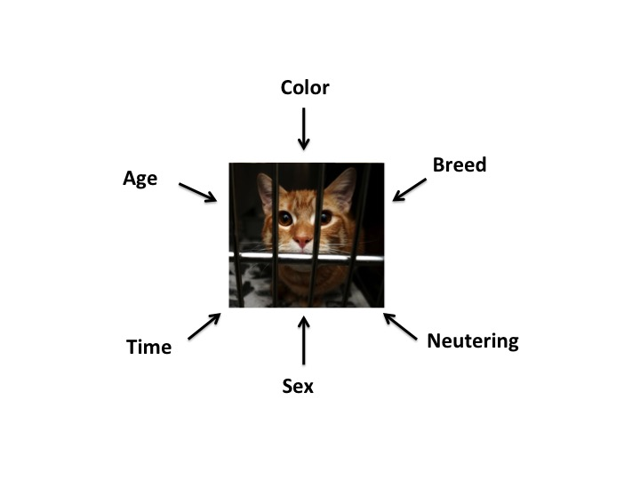

## Cats vs. Dogs

This dataset contains 11134 cats and 15595 dogs

[interactive chart not shown]

## Does Name Matter?

Created a new varible "hasName" ("No"= NA, "Yes"= has a name)

[interactive chart not shown]

## Does Name Matter? (%)

Created a new varible "hasName" ("No"= NA, "Yes"= has a name)

[interactive chart not shown]

## Does Sex Matter?

Seperated "SexType" to "Sex" and "isNeutered"

[interactive chart not shown]

## Does Sex Matter? (%)

Seperated "SexType" to "Sex" and "isNeutered"

[interactive chart not shown]

## Does Spaying/Neutering Matter?

Seperated "SexType" to "Sex" and "isNeutered"

[interactive chart not shown]

## Does Spaying/Neutering Matter? (%)

Seperated "SexType" to "Sex" and "isNeutered"

[interactive chart not shown]

## Does Mixed Breed Matter?

Seperated "BreedType" to "isMix" and "Breed"

[interactive chart not shown]

## Does Mixed Breed Matter? (%)

Seperated "BreedType" to "isMix" and "Breed"

[interactive chart not shown]

## Does Breed Matter? (Cats)

Top eight popular breeds are selected

[interactive chart not shown]

## Does Breed Matter? (Cats)

Top eight breeds are selected

[interactive chart not shown]

## Does Breed Matter? (Dogs)

Top eight breeds are selected

[interactive chart not shown]

## Does Breed Matter? (Dogs)

Top eight breeds are selected

[interactive chart not shown]

## Does Age Matter? (By year)

Converted "AgeuponOutcome" to "ageInDay", "ageInWeek", "ageInMonth", and "ageInYear"

[interactive chart not shown]

## Does Age Matter? (By year) (%)

Converted "AgeuponOutcome" to "ageInDay", "ageInWeek", "ageInMonth", and "ageInYear"

[interactive chart not shown]

## Does Age Matter? (By month)

[interactive chart not shown]

## Does Age Matter? (By month) (%)

[interactive chart not shown]

## Does Outcome Time Matter? (By hour)

Converted "OutcomeDateTime" to POSIXlt (datetime format)

[interactive chart not shown]

## Does Outcome Time Matter? (By weekday)

[interactive chart not shown]

## Does Outcome Time Matter? (By month)

[interactive chart not shown]

## Heat Map of Adoption: weekday vs. hour

[interactive chart not shown]

## Conclusions

- "Age", "OutcomeTime", "isNeutered" might be driving factors
- "Sex" and "isMix" might not be important ….
- "hasName" and "Breed" may result in differet outcomes between Cats and dogs

## Future work

- Missing values imputation
- Statistic analysis (e.g. Chi-square test, ANOVA. etc.)
- Multiclass classification (e.g. randomForest, XGboost, etc.)